# TW3_Meetkunde

Nico Booij

17 November 2020

# 1 TW3 Meetkunde.

De module meetkunde heeft als doel studenten te laten rekenen aan afstanden en richtingen op de aarde. Daarbij wordt aangenomen dat de aarde een bol is. Dit is van belang bij de optimalisatie van routes van vliegtuigen en schepen. De optimalisatie resulteert in brandstof- en tijdbesparing. In de huidige economische situatie zeer actueel.

Met behulp van boldriehoeksmeting kun je afstand en richting op de bol berekenen. Daarbij wordt onderscheid gemaakt tussen rechthoekige- en scheefhoekige boldriehoeken.

Let op!: Deze LectureNotes zijn nog niet compleet. Dit heeft te maken met de omzetting van de module naar de Teams omgeving. Je krijgt echter wel een beeld van de inhoud van de module.

## 1.1 Welke onderdelen zitten er in de module?

In de module zitten de volgende onderdelen:

- Coordinaten: Pool, Bol en cilinder.
- Grootcirkel
- Loxodroom
- Boldriehoeksmeting (B3HM).

## 1.2 Docenten

De module wordt gegeven door de volgende docent:

- Nico Booij.

De docent is als volgt te bereiken:

- Mobiel: 0614309256
- Email: nico.booij@nhlstenden.com

# 2 Informatie en lesmateriaal.

Tijdens de lessen maken we gebruik van:

- Google Earth.
- OpenCPN.
- Boeken.
- Blackboard
- Microsoft Teams
- Mobius
- Scilab
- YouTube

[figure not shown]

## 2.1 Google Earth.

Installeer [Google Earth](https://www.google.nl/intl/nl/earth/) op je computer.

## 2.2 OpenCPN.

Naast Google Earth maak je gebruik van de software van [OpenCPN](https://opencpn.org/index.html). Dit is een navigatieprogramma dat wordt gebruikt aan boord van schepen. Je kunt elektronische kaarten weergeven, maar ook berekeningen uitvoeren. In deze module gaat het om de berekeningen, waarmee je de uitkomsten van je eigen berekeningen kunt controleren. Daarnaast krijg je een goed beeld van de posities van je coordinaten.

- Installeer [OpenCPN](https://opencpn.org/OpenCPN/info/downloads.html).

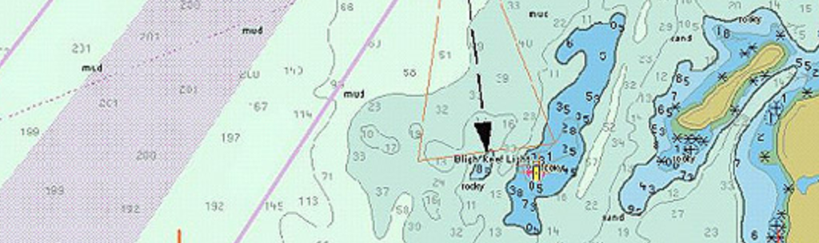

## 2.3 Boeken.

Hieronder een overzicht van de literatuur die tijdens de lessen wordt gebruikt:

- [1] Steward, James Steward (2015). "Calculus".
- [2] Fenna, Donald (2007). "Cartographic Science".
- [3] Tjepkema, H. (1941), "Leerboek der Zeevaartkunde", J. Noorduijn & Z.
- [4] Draaisma, (1982), "Leerboek 1 Navigatie", De Boer Maritiem.

De boeken [2,3,4] zijn naslagwerken en hoeven niet te worden aangeschaft. Per les zijn de onderdelen middels een downloadling beschikbaar in [Mobius](https://nhltechniek.mobius.cloud/login).

## 2.4 Blackboard.

In Blackboard vind je alle inhoud van de module en heeft de naam: TW3 Meetkunde (TW3_Meetkunde TECH_MI_12_183).  
De digitale lessen worden gegeven in Teams.

## 2.5 Microsoft Teams.

Microsoft teams is een erg handig communicatieplatform. Dit zullen we gebruiken voor de digitale lessen, communicatie tussen docent en studenten (onderling). De Teams omgeving is beschikbaar onder de volgende link: [Microsoft Teams](https://teams.microsoft.com/l/team/19%3a4c0556b1db424c1991f023c7c3b9d088%40thread.tacv2/conversations?groupId=f3b404f2-d530-48a5-9720-d9a95d6fed38&tenantId=016a9e48-ba0b-49f4-97f8-a88352164e58)

## 2.6 Mobius

Mobius wordt gebruik als de online oefen-en toetsomgeving. Hier vind je per les een aantal digitale vragen. Mobius is te vinden onder de link [Mobius](https://nhltechniek.mobius.cloud/login). Je vindt de klas "TW3_Meetkunde_2021" m.b.v. de [Classlink](https://nhltechniek.mobius.cloud/class/LUCKJ).

## 2.7 Scilab

Voor de uitvoering van de berekeningen maak je gebruik van [Scilab](https://www.scilab.org/). Je gebruikt Scilab ook voor je eindopdracht. De code lever je dan als apart bestand in; zie instructies eindopdracht. Tijdens de lessen wordt er aandacht besteedt aan het werken met Scilab. Het is wel handig om een paar naslagwerken te hebben. Hieronder staan een paar handige linkjes. Het is niet nodig om alles door te nemen. Gebruik dat wat je nodig hebt voor de opdrachten.

- [Scilab voor beginners](https://www.scilab.org/tutorials/scilab-beginners-%E2%80%93-tutorial)
- [Overzicht van tutorials voor Scilab](https://www.scilab.org/tutorials)

Per les zal worden aangegeven wat je kunt gebruiken bij het uitvoeren van de berekeningen.

[figure not shown]

Scilab is freeware software, vergelijkbaar met [Matlab](https://nl.mathworks.com/?s_tid=gn_logo), de industriele standaard, maar niet goedkoop. Andere alternatieven voor matlab zijn [Octave](https://www.gnu.org/software/octave/index) en [Freemat](http://freemat.sourceforge.net/#home).

In deze module maken we gebruik van Scilab.

## 2.8 YouTube

Op het [YouTube kanaal](https://www.youtube.com/user/nicobooij) van de docent kun je screencasts (Korte filmpjes) kijken met daarop uitleg over de sommen. Per les worden de linkjes aangeboden.

# 3 Afronding van de module.

De module kent twee beoordelingen:

- Digitale huiswerkopdrachten
- Eindopdracht met Scilab

## 3.1 Digitale huiswerkopdrachten.

De digitale huiswerkopdrachten moeten allemaal zijn afgerond met tenminste de aangegeven score. In de meeste gevallen is de score 80%. Afronding van deze opdrachten geeft je toegang tot de eindopdracht.  
Met de komst van digitale toetsen zien we dat studenten minder aandacht besteden aan de uitwerking van sommen. Stagebedrijven geven aan dat deze uitwerkingen erg belangrijk zijn. HBO studenten moeten de uitwerkingen begrijpelijk kunnen delen met het team waarin ze werken.  
De eindopdracht bestaat uit een random selectie van de huiswerkopdrachten. Hierbij lever je de handgeschreven uitwerkingen in. Het kan zijn dat je digitaal voldoende punten haalt, maar toch een onvoldoende krijgt omdat je uitwerkingen onvoldoende zijn.

Als je de eindopdracht wilt maken volg je het volgende stappenplan:

- Open de toets in [Mobius](https://nhltechniek.mobius.cloud/login).
- Maak de vragen.
- Schrijf bij elke vraag steeds de uitwerking op.
- Maak foto's van je uitwerkingen.
- Importeer de foto's in een word-document.
- Zorg dat bovenaan het bestand je naam, studentnummer en klas staat.
- Sla het bestand op als PDF onder de naam: TW3_Meetkunde_2021_Tentamen_JeNaam_YYMMDD
- Mail het PDF bestand (Geen Word bestanden!) binnen 20 minuten naar de docent.

## 3.2 Eindopdracht met Scilab

De eindopdracht voldoet aan:

- De eindopdracht maak je alleen.
- Je maakt de opdracht in een voorbewerkt bestand in Scinotes (Scilab).
- Voorzie je de code van voldoende commentaarregels, zodat deze te begrijpen is voor medestudenten en docent.
- Sla de opdracht op als TW3_Meetkunde_2021_Assignment_JeNaam_YYMMDD.sce
- Vul de gegevens in op de opdracht.
- Maak de opdachten en controleer of deze ook goed werken.
- Lever de opdracht in via de mail.

De eindopdracht is voldoende bij tenminste 70% scoren van het totaal aantal punten. Voor de beoordeling wordt gebruik gemaakt van een rubric in Mobius.

# 4 Wat gaan we doen tijdens de lessen?

Hieronder zie je een overzicht van de lessen per week. In het schooljaar 20/21 worden de lessen online gegeven in Teams.

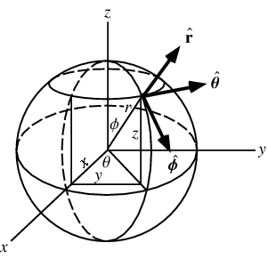

## 4.1 Week 1: Polar Coordinates and Conic Sections.

Deze week krijg je een introductie van de module en voer je de eerste berekenigen uit met matrices.

### 4.1.1 Wat gaan we doen?

We gaan het volgende doen tijdens de les:

- Introductie OpenCPN.
- Cilinder- en bolcoordinaten.
- Bolcoordinaten in navigatie.
- Nautische mijl.
- Grootcirkelafstand m.b.v. inwendig product.

### 4.1.2 Wat moet ik bestuderen?

Bestudeer van [1] Steward (2015!):

- [1] Calculus oude editie :12.8 Cylindrical and spherical coordinates.
- [2] Fenna, Donald (2007). "Carthographic Science".
- [Coordinaten stelsels op aarde](https://en.wikipedia.org/wiki/Geographic_coordinate_system).
- [Nautische mijl](https://en.wikipedia.org/wiki/Nautical_mile).

Deze documenten zijn als download beschikbaar op [Mobius](https://nhltechniek.mobius.cloud/login).

### 4.1.3 Welke sommen doen we tijdens de les?

Tijdens de les werken we aan de volgende opdrachten:

- Omrekenen van bol naar XYZ coordinaten.
- Omrekenen van Cilinder naar XYZ coordinaten.
- Coordinatenstelsel op Aarde.
- Nautische mijn (nm).
- Afstanden m.b.v. inwendig product.
1. Bepaal de XYZ-coordinaten van New Orleans $30^{\circ} 00.0'N / 090^{\circ} 00.0'W$. Neem aan dat de aarde een bol is met een straal van 4000 mijl.
2. Bepaal de kortste afstand over de aardbol ($R=6370 km$) tussen de twee volgende punten:
- A: $40^{\circ} 00.0'N / 060^{\circ} 00.0'W$
- B: $20^{\circ} 00.0'N / 040^{\circ} 00.0'W$

### 4.1.4 Waar kan ik de filmpjes vinden?

Er zijn van een aantal onderdelen filmpjes gemaakt:

- t.b.d.

### 4.1.5 Scilab.

Voor het maken van de opdracht kun je gebruik maken van de volgende Scilab-document(en):

- [Vectoren met Scilab](http://math.hawaii.edu/~gautier/math_190_lecture_2.pdf).

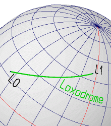

## 4.2 Week 2: Loxodroom.

Deze week leer je hoe je afstand en richting kunt bepalen m.b.v. een [Loxodroom](https://nl.wikipedia.org/wiki/Loxodroomnavigatie).

### 4.2.1 Wat gaan we doen?

We gaan het volgende doen tijdens de les:

- Wat is een loxodroom?
- Afstanden Noord-Zuid.
- Afstanden Oost-West.
- Schuine afstanden en richtingen.

### 4.2.2 Wat moet ik bestuderen?

Bestudeer van [4] Draaisma "Leerboek Navigatie":

- 5.3 Loxodroomnavigatie.

### 4.2.3 Welke sommen doen we tijdens de les?

Tijdens de les werken we aan de volgende opdrachten:

Gegeven de volgende coordinaten:

- Texel: $52^{\circ} 58.2'N / 004^{\circ} 13.8'E$
- Stavanger: $58^{\circ} 54.6'N / 004^{\circ} 13.8'E$
- Edinburgh: $56^{\circ} 08.6'N / 002^{\circ} 39.5'E$
- Pentland Firth: $58^{\circ} 54.6'N / 003^{\circ} 06.9'E$

Bereken de afstand en richting via loxodroom van:

1. Texel naar Stavanger.
2. Stavanger naar Penthland Firth.
3. Stavanger naar Edinburgh.
4. Welke positie heeft een schip dat vanuit Stavanger naar Edinburgh vaart met 21 knopen?

### 4.2.4 Waar kan ik de filmpjes vinden?

Er zijn van een aantal onderdelen filmpjes gemaakt:

[Playlist Loxodroom](https://www.youtube.com/playlist?list=PLeqVMQGMRe7ZSAEcJkH31dJmKWw5p7VGm)

### 4.2.5 Scilab.

Werk de opdrachten van de workout uit m.b.v. Scilab en controleer je antwoorden.

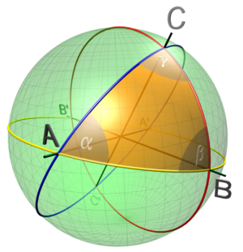

## 4.3 Week 3: Introductie Boldriehoeksmeting (B3HM).

Deze week krijg je een introductie van de boldriehoeksmeting (B3HM).

### 4.3.1 Wat gaan we doen?

We gaan het volgende doen tijdens de les:

- Introductie.
- Begrippen.
- Nevendriehoek.
- Topdriehoek.
- Tegendriehoek.
- Oppervlakte boldriehoek.
- Eigenschappen van een boldriehoek.
- Gelijkvormigheid van boldriehoeken.

### 4.3.2 Wat moet ik bestuderen?

- paragraaf 54: "Eigenschappen van bolfiguren".
- para 56: de boltweehoek.
- para 57: de boldriehoek.
- para 58: de pooldriehoek.
- para 59: de oppervlakte van de boldriehoek.

### 4.3.3 Welke sommen doen we tijdens de les?

Tijdens de les werken we aan de volgende opdrachten:

- t.b.d.

### 4.3.4 Waar kan ik de filmpjes vinden?

Er zijn van een aantal onderdelen filmpjes gemaakt:

[Playlist B3HM](https://www.youtube.com/playlist?list=PLeqVMQGMRe7ZIW0rYB_O4LQ_2fSFv3oG8)

### 4.3.5 Scilab.

- t.b.d.

## 4.4 Week 4: Rechthoekige boldriehoeken.

### 4.4.1 Wat gaan we doen?

We gaan het volgende doen tijdens de les:

- Rechthoekige boldriehoeken.
- Scherpe of stompe hoeken.

### 4.4.2 Wat moet ik bestuderen?

- para 60: Eigenschappen van de zijden van een boldriehoek.
- para 61: Eigenschappen van de hoeken van een boldriehoek.
- para 61: Gelijk-en gelijkvormigheid van boldriehoeken.
- para 63: de formules van rechthoekige boldriehoeken.

### 4.4.3 Welke sommen doen we tijdens de les?

Tijdens de les werken we aan de volgende opdrachten:

- t.b.d.

### 4.4.4 Waar kan ik de filmpjes vinden?

Er zijn van een aantal onderdelen filmpjes gemaakt:

[Playlist B3HM](https://www.youtube.com/playlist?list=PLeqVMQGMRe7ZIW0rYB_O4LQ_2fSFv3oG8).

### 4.4.5 Scilab.

- t.b.d.

## 4.5 Week 5: Scheefhoekige boldriehoeken.

### 4.5.1 Wat gaan we doen?

We gaan het volgende doen tijdens de les:

- Scheefhoekige boldriehoeken.
- Sferische loodlijn.
- Eerste cosinusregel.
- Grootcirkel.

### 4.5.2 Wat moet ik bestuderen?

- para 64: de formules van scheefhoekige boldriehoeken.
- para 65 Eerste cosinusregel.
- para 66: Tweede cosinusregel.
- para 67: Sinusregel.
- para 67: Tangensregel.

### 4.5.3 Welke sommen doen we tijdens de les?

Tijdens de les werken we aan de volgende opdrachten:

- t.b.d.

### 4.5.4 Waar kan ik de filmpjes vinden?

Er zijn van een aantal onderdelen filmpjes gemaakt:

- t.b.d.

## 4.6 Week 6 t/m 8: Werken aan Toepassing.

# 5 Scilab opdrachten.

Hier vind je de opdrachten die je moet maken m.b.v. Scilab. Verzamel je opdrachten in een digitaal portfolio. Voor de afronding van de module lever je dit portfolio in.

## 5.1 Opdracht 1: Grootcirkel afstand met inwendig product.

Schrijf een scilab code waarmee je de kortste afstand tussen twee punten op aarde kunt berekenen m.b.v. het inwendig product.

## 5.2 Opdracht 2: Loxodroom.

Schrijf een Scilab code waarmee je de afstand en richting over de loxodroom tussen twee punten op aarde kunt berekenen.

## 5.3 Opdracht 3:

t.b.d.

## 5.4 Eindopdracht.

t.b.d.

# 6 Scilab codes.

## 6.1 Header Scilab codes.

```
//TW3_Meetkunde 20/21
//YYMMDD: datum
//Naam: Jouw Naam
//Titel: Header voor Scilab opdrachten
//Reference: Plaats hier je linkjes naar websites
//
clc
clear
//Opdracht ..
disp("Opdracht ..")


//EOF
```

## 6.2 Werken met vectoren.

```
//TW3_Meetkunde
//Date (YYMMDD): 201111
//Nico Booij
//Subject: Calculations with vectors
//Reference:
//
//+++++++++++++++++++++++++++++++++++++++++++++++++++++++++++
//
clc
clear
//How to create a vector?
disp("1.How to create a vector?")
a=[1,2,3] //row vector
b=[1,1,1]
disp(b,"b=",a,"a=")
//2. Add two vectors:
disp("2.Add two vectors:")
sum=a+b
disp(sum,"sum=")
//Multiply by scalar:
disp("3.Multiply by scalar:")
scalar=2
scalar*a
disp(scalar*a,"=",a,"*",scalar)
//Length of a vector:
disp("4.Length of vector a equals:")
norm(a)
disp(norm(a),"Length of vector a equals:")
//Unit vector:
disp("5.Unit vector:")
ea=a/norm(a)
disp(ea,"unit vecotr of a equals:")
disp(norm(ea),"unit vector has length:")
//Dot product:
disp("6.Dot product:")
a*b'
disp(a*b',"dotproduct of a and b:")
//Angle between two vectors:
disp("7.Angle between two vectors:")
costheta=a*b'/(norm(a)*norm(b))
theta_rad=acos(costheta)
theta_deg=theta_rad*180/%pi
disp(theta_deg,"Angle between a and b equals:")
//Projection of two vectors:
Pa_b=a*b'/norm(a)
disp(Pa_b,"Projection of a on b equals:")
//EOF
```